# Assignment 3

STATS 220 Semester One 2022

Nev Erkam Yildirim

## Introduction

- Since my childhood and through my adolescence, I have always been a big fan of Harry Potter book and movie series and, therefore, have decided to choose the word **Harry Potter** in my book search through [Google Books API](https://books.google.com/) and [board game geek website](https://boardgamegeek.com/).
- Of course, at first glance, I am expecting both the book and the game to have exactly the same characters, the same features for those characters, and both to follow a similar plot line. The difference might be that the board game might equip some characters with some additional powers or might divert a little from the original plot line just to make a game out of it all.

## Book data

### Sourcing data from the Google Books API

```r
query <- "https://www.googleapis.com/books/v1/volumes?q=intitle:%22harry+potter%22&startIndex=1&maxResults=40"

response <- fromJSON(query, flatten = TRUE)

book_data <- response$items

book_data %>%
  select(volumeInfo.title, volumeInfo.publishedDate) %>%
  knitr::kable()
```

| volumeInfo.title | volumeInfo.publishedDate |
| --- | --- |
| The Psychology of Harry Potter | 2007-04-10 |
| Harry Potter and the Philosopher’s Stone | 2014-01-09 |
| Harry Potter and the Sorcerer’s Stone | 1998 |
| Harry Potter and Philosophy | 2004 |
| Livro - Coleção Harry Potter (7 Volumes). | 2015 |
| Harry Potter and the Half-Blood Prince | 2018-06-26 |
| Harry Potter and the Chamber of Secrets | 1999 |
| Harry Potter: Exploring Hogwarts | 2019-10-08 |
| Harry Potter and the Millennials | 2013-08-15 |
| Harry Potter and the Deathly Hallows | 2014-08-27 |
| Harry Potter: The Complete Collection (1-7) | 2015-12-14 |
| The Gospel According to Harry Potter | 2008 |
| Harry Potter: Coloring Wizardry | 2020-10-13 |
| Harry Potter: Knitting Magic: More Patterns From Hogwarts and Beyond | 2021-10-26 |
| Harry Potter and the Prisoner of Azkaban | 2016-06-22 |
| Harry Potter and the Goblet of Fire: The Illustrated Edition | 2019-10-08 |
| Harry Potter and the Chamber of Secrets - Hufflepuff Edition | 2018-06-28 |
| Harry Potter and the Half-Blood Prince - Ravenclaw Edition | 2021-01-21 |
| Harry Potter Page to Screen: Updated Edition | 2018-11-13 |
| Harry Potter | 2017 |
| Harry Potter and the Philosopher’s Stone - Gryffindor Edition | 2017-06 |
| Special Edition Harry Potter Paperback Box Set | 2013-08-27 |
| Harry Potter: Crochet Wizardry \| Crochet Patterns \| Harry Potter Crafts | 2021-08-17 |
| Harry Potter and the Deathly Hallows - Gryffindor Edition | 2021 |
| LEGO(R) Harry Potter(TM): Magical Adventures at Hogwarts | 2021-02-16 |
| Harry Potter and the Prisoner of Azkaban - Gryffindor Edition | 2019-06-13 |
| Harry Potter, science ou sorcellerie ? | 2019-10-21 |
| Harry Potter - The Illustrated Collection | 2017-11-16 |
| Harry Potter e a pedra filosofal | 1999 |
| Harry Potter: Knitting Magic | 2020-01-28 |
| Harry Potter and the Order of the Phoenix | 2013-08-27 |
| The Harry Potter Collection | 2006-09-01 |
| Harry Potter and the Philosopher’s Stone - Hufflepuff Edition | 2017-06 |
| Harry Potter and the Goblet of Fire - Gryffindor Edition | 2020-01-23 |
| Harry Potter and the Deathly Hallows - Slytherin Edition | 2021-06-10 |
| Harry Potter Gryffindor House Editions Hardback Box Set | 2021-11-11 |
| Harry Potter and the Prisoner of Azkaban - Hufflepuff Edition | 2019-06-13 |
| Harry Potter and the Philosopher’s Stone (Irish) | 2015-01-29 |
| Harry Potter Colouring Book | 2016-03 |
| The Science of Harry Potter | 2017-11-14 |

### Creating a new data frame

```r
mini_data <- book_data %>%
              select(volumeInfo.title,
                     volumeInfo.pageCount,
                     volumeInfo.publishedDate,
                     volumeInfo.publisher,
                     volumeInfo.averageRating,
                     volumeInfo.description) %>%
              rename(book_title = volumeInfo.title,
                     page_count = volumeInfo.pageCount,
                     published_date = volumeInfo.publishedDate,
                     publisher = volumeInfo.publisher,
                     average_rating = volumeInfo.averageRating,
                     description = volumeInfo.description) %>%
              mutate(published_date = as.Date(published_date))

mini_data <- mini_data %>%
  arrange(page_count)

mini_data %>%
  knitr::kable()
```

| book_title | page_count | published_date | publisher | average_rating | description |
| --- | --- | --- | --- | --- | --- |
| The Harry Potter Collection | 6 | 2006-09-01 | Scholastic Paperbacks | 4.5 | Collects in a boxed set the first six books in the series that relates the adventures of young Harry Potter, who attends Hogwarts School of Witchcraft and Wizardry, where he and others of his kind lea… |
| LEGO(R) Harry Potter(TM): Magical Adventures at Hogwarts | 32 | 2021-02-16 | Simon and Schuster | NA | Get ready for the ultimate wizarding fun in this awesome LEGO(R) Harry Potter(TM) activity book with everything you need to build your own LEGO minifigure! Join Harry, Hermione, Ron, and more of your … |
| Harry Potter: Exploring Hogwarts | 48 | 2019-10-08 | Insight Kids | 4.0 | Explore the iconic locations of Hogwarts as seen in the Harry Potter films with this large-scale interactive book, Harry Potter: Exploring Hogwarts. Harry Potter: Exploring Hogwarts pairs striking ful… |
| Harry Potter: Coloring Wizardry | 96 | 2020-10-13 | Simon and Schuster | NA | Bursting with beautiful, exclusive illustrations, Harry Potter: Coloring Wizardry is a must-have coloring book for fans of the magical film series. Escape to one of the most beloved series of all time… |
| Harry Potter Colouring Book | 96 | NA | NA | NA | NA |
| Harry Potter and the Millennials | 118 | 2013-08-15 | JHU Press | NA | Harry Potter and the Millennials tells the fascinating story of how the team designed the study and gathered results, explains what conclusions can and cannot be drawn, and reveals the challenges soci… |
| Harry Potter | 144 | NA | Bloomsbury Publishing | 2.0 | “An irresistible romp through the history of magic, from alchemy to unicorns, ancient witchcraft to Harry’s Hogwarts - packed with unseen sketches and manuscript pages from J.K. Rowling, magical illus… |
| Harry Potter: Crochet Wizardry \| Crochet Patterns \| Harry Potter Crafts | 176 | 2021-08-17 | Simon and Schuster | NA | “From the films of Harry Potter”–Cover. |
| Harry Potter: Knitting Magic | 192 | 2020-01-28 | Insight Editions | NA | Introducing the first official Harry Potter knitting book—a deluxe guide to creating over 25 authentic Harry Potter knits based on the iconic films. Channel the magic of the Harry Potter films from th… |
| Harry Potter e a pedra filosofal | 207 | NA | NA | NA | Rescued from the outrageous neglect of his aunt and uncle, a young boy with a great destiny proves his worth while attending Hogwarts School for Wizards and Witches. |
| Harry Potter: Knitting Magic: More Patterns From Hogwarts and Beyond | 224 | 2021-10-26 | Simon and Schuster | NA | “Also includes patterns from Fantastic Beasts”–Cover. |
| The Science of Harry Potter | 224 | 2017-11-14 | Racehorse | NA | How does magic in J. K. Rowling’s universe work? Finally, the scientific secrets are revealed! The story of the boy who lived has brought the idea of magic and sorcery into mainstream fruition more th… |
| Harry Potter and Philosophy | 243 | NA | Open Court Publishing | 3.5 | Urging readers of the Harry Potter series to dig deeper than wizards, boggarts, and dementors, the authors of this unique guide collect the musings of seventeen philosophers on the series, who cover a… |
| Harry Potter and the Chamber of Secrets | 251 | NA | Raincoast Books | 4.5 | Witchcraft, wizardry - fiction. |
| Harry Potter and the Philosopher’s Stone (Irish) | 272 | 2015-01-29 | Bloomsbury Children’s Books | 5.0 | Bhí cónaí ar mhuintir Dursley in uimhir a ceathair Privet Drive …’ The first words of J.K. Rowling’s timeless classic are familiar to readers the world over as ‘Mr and Mrs Dursley, of number four, Pri… |
| Harry Potter, science ou sorcellerie ? | 296 | 2019-10-21 | De Boeck Superieur | NA | C’est l’univers incroyable et magique que se proposent de décortiquer les deux auteurs de l’ouvrage en offrant la possibilité à tous ceux qui ont été bercés par le monde ensorcelant de J.K. Rowling de… |
| The Gospel According to Harry Potter | 305 | NA | Westminster John Knox Press | 5.0 | Tagline: Now Exploring Books One through Seven |
| Harry Potter and the Sorcerer’s Stone | 309 | NA | Arthur A. Levine Books | 4.5 | Rescued from the outrageous neglect of his aunt and uncle, a young boy with a great destiny proves his worth while attending Hogwarts School for Witchcraft and Wizardry. |
| The Psychology of Harry Potter | 326 | 2007-04-10 | BenBella Books | 3.5 | Harry Potter has provided a portal to the wizarding world for millions of readers, but an examination of Harry, his friends and his enemies will take us on yet another journey: through the psyche of t… |
| Harry Potter and the Philosopher’s Stone | 352 | 2014-01-09 | Bloomsbury Publishing | 5.0 | Celebrate 20 years of Harry Potter magic! Harry Potter has never even heard of Hogwarts when the letters start dropping on the doormat at number four, Privet Drive. Addressed in green ink on yellowish… |
| Harry Potter and the Philosopher’s Stone - Gryffindor Edition | 368 | NA | Bloomsbury Childrens | NA | Celebrate 20 years of Harry Potter magic with four special editions ofHarry Potter and the Philosopher’s Stone. Gryffindor, Slytherin, Hufflepuff, Ravenclaw … Twenty years ago these magical words and … |
| Harry Potter and the Philosopher’s Stone - Hufflepuff Edition | 368 | NA | Bloomsbury Children’s Books | NA | Gryffindor, Slytherin, Hufflepuff, Ravenclaw … Twenty years ago these magical words and many more flowed from a young writer’s pen, an orphan called Harry Potter was freed from the cupboard under the … |
| Harry Potter and the Chamber of Secrets - Hufflepuff Edition | 384 | 2018-06-28 | Bloomsbury Publishing | NA | This Hufflepuff edition is published to mark the 20th anniversary of first publication of Harry Potter and the Chamber of Secrets. Relish great Hufflepuff moments - repotting Mandrakes with Professor … |
| Harry Potter and the Goblet of Fire: The Illustrated Edition | 464 | 2019-10-08 | Arthur A. Levine Books | NA | The fourth book in the beloved Harry Potter series, now illustrated in glorious full color by award-winning artist Jim Kay. Harry Potter wants to get away from the pernicious Dursleys and go to the In… |
| Harry Potter and the Prisoner of Azkaban - Hufflepuff Edition | 465 | 2019-06-13 | Bloomsbury Children’s Books | NA | Let the magic of J.K. Rowling’s classic Harry Potter series take you back to Hogwarts School of Witchcraft and Wizardry. Issued to mark the 20th anniversary of first publication ofHarry Potter and the… |
| Harry Potter and the Prisoner of Azkaban | 480 | 2016-06-22 | NA | 4.5 | ‘Welcome to the Knight Bus, emergency transport for the stranded witch or wizard. Just stick out your wand hand, step on board and we can take you anywhere you want to go.’ When the Knight Bus crashes… |
| Harry Potter and the Prisoner of Azkaban - Gryffindor Edition | 480 | 2019-06-13 | Bloomsbury Children’s Books | NA | NA |
| Harry Potter Page to Screen: Updated Edition | 540 | 2018-11-13 | Harper Design | NA | Harry Potter Page to Screen: Revised and Expanded now has more pages devoted to the legacy of the Harry Potter films. In addition to the complete history of all eight Harry Potter films, the book now … |
| Harry Potter and the Half-Blood Prince - Ravenclaw Edition | 546 | 2021-01-21 | Bloomsbury Children’s Books | NA | Suspicion and fear blow through the wizarding world as news of the Dark Lord’s attack on the Ministry of Magic spreads. Harry has not told anyone about the future predicted by the prophecy in the Depa… |
| Harry Potter and the Deathly Hallows | 619 | 2014-08-27 | Bloomsbury Publishing | 4.5 | Celebrate 20 years of Harry Potter magic! As he climbs into the sidecar of Hagrid’s motorbike and takes to the skies, leaving Privet Drive for the last time, Harry Potter knows that Lord Voldemort and… |
| Harry Potter and the Goblet of Fire - Gryffindor Edition | 627 | 2020-01-23 | Bloomsbury Children’s Books | NA | Harry Potter joins the Weasleys at the Quidditch World Cup, then enters his fourth year at Hogwarts Academy where he is mysteriously entered in an unusual contest that challenges his wizarding skills,… |
| Harry Potter and the Deathly Hallows - Gryffindor Edition | 640 | NA | Bloomsbury Children’s Books | NA | NA |
| Harry Potter and the Deathly Hallows - Slytherin Edition | 640 | 2021-06-10 | Bloomsbury Children’s Books | NA | NA |
| Harry Potter and the Half-Blood Prince | 688 | 2018-06-26 | Arthur A. Levine Books | 4.0 | A special new edition in celebration of the 20th anniversary of the publication of Harry Potter and the Sorcerer’s Stone, with a stunning new cover illustration by Caldecott Medalist Brian Selznick. T… |
| Harry Potter and the Order of the Phoenix | 870 | 2013-08-27 | Scholastic Paperbacks | 4.0 | As Harry faces his upcoming fifth year at Hogwarts Academy, there are increasing rumors of dark times coming and of Lord Voldemort’s return to power, and a secret anti-Voldemort society, The Order of … |
| Harry Potter Gryffindor House Editions Hardback Box Set | 3888 | 2021-11-11 | Bloomsbury Children’s Books | NA | NA |
| Harry Potter: The Complete Collection (1-7) | 4236 | 2015-12-14 | Pottermore Publishing | 4.0 | All seven eBooks in the multi-award winning, internationally bestselling Harry Potter series, available as one download with stunning cover art by Olly Moss. Enjoy the stories that have captured the i… |
| Livro - Coleção Harry Potter (7 Volumes). | NA | NA | NA | NA | NA |
| Special Edition Harry Potter Paperback Box Set | NA | 2013-08-27 | NA | 5.0 | Collects the complete series that relates the adventures of young Harry Potter, who attends Hogwarts School of Witchcraft and Wizardry, where he and others of his kind learn their craft. |
| Harry Potter - The Illustrated Collection | NA | 2017-11-16 | Bloomsbury Publishing | 5.0 | NA |

### Mutating new variables

```r
mutated_data <- mini_data %>%
  mutate(year_published = str_sub(published_date, 1, 4) %>% as.numeric(),
         month_published = str_sub(published_date, 6, 7) %>% as.numeric(),
         day_published = str_sub(published_date, 9, 10) %>% as.numeric(),
         title_length = nchar(book_title))

mutated_data %>% knitr::kable()
```

| book_title | page_count | published_date | publisher | average_rating | description | year_published | month_published | day_published | title_length |
| --- | --- | --- | --- | --- | --- | --- | --- | --- | --- |
| The Harry Potter Collection | 6 | 2006-09-01 | Scholastic Paperbacks | 4.5 | Collects in a boxed set the first six books in the series that relates the adventures of young Harry Potter, who attends Hogwarts School of Witchcraft and Wizardry, where he and others of his kind lea… | 2006 | 9 | 1 | 27 |
| LEGO(R) Harry Potter(TM): Magical Adventures at Hogwarts | 32 | 2021-02-16 | Simon and Schuster | NA | Get ready for the ultimate wizarding fun in this awesome LEGO(R) Harry Potter(TM) activity book with everything you need to build your own LEGO minifigure! Join Harry, Hermione, Ron, and more of your … | 2021 | 2 | 16 | 56 |
| Harry Potter: Exploring Hogwarts | 48 | 2019-10-08 | Insight Kids | 4.0 | Explore the iconic locations of Hogwarts as seen in the Harry Potter films with this large-scale interactive book, Harry Potter: Exploring Hogwarts. Harry Potter: Exploring Hogwarts pairs striking ful… | 2019 | 10 | 8 | 32 |
| Harry Potter: Coloring Wizardry | 96 | 2020-10-13 | Simon and Schuster | NA | Bursting with beautiful, exclusive illustrations, Harry Potter: Coloring Wizardry is a must-have coloring book for fans of the magical film series. Escape to one of the most beloved series of all time… | 2020 | 10 | 13 | 31 |
| Harry Potter Colouring Book | 96 | NA | NA | NA | NA | NA | NA | NA | 27 |
| Harry Potter and the Millennials | 118 | 2013-08-15 | JHU Press | NA | Harry Potter and the Millennials tells the fascinating story of how the team designed the study and gathered results, explains what conclusions can and cannot be drawn, and reveals the challenges soci… | 2013 | 8 | 15 | 32 |
| Harry Potter | 144 | NA | Bloomsbury Publishing | 2.0 | “An irresistible romp through the history of magic, from alchemy to unicorns, ancient witchcraft to Harry’s Hogwarts - packed with unseen sketches and manuscript pages from J.K. Rowling, magical illus… | NA | NA | NA | 12 |
| Harry Potter: Crochet Wizardry \| Crochet Patterns \| Harry Potter Crafts | 176 | 2021-08-17 | Simon and Schuster | NA | “From the films of Harry Potter”–Cover. | 2021 | 8 | 17 | 71 |
| Harry Potter: Knitting Magic | 192 | 2020-01-28 | Insight Editions | NA | Introducing the first official Harry Potter knitting book—a deluxe guide to creating over 25 authentic Harry Potter knits based on the iconic films. Channel the magic of the Harry Potter films from th… | 2020 | 1 | 28 | 28 |
| Harry Potter e a pedra filosofal | 207 | NA | NA | NA | Rescued from the outrageous neglect of his aunt and uncle, a young boy with a great destiny proves his worth while attending Hogwarts School for Wizards and Witches. | NA | NA | NA | 32 |
| Harry Potter: Knitting Magic: More Patterns From Hogwarts and Beyond | 224 | 2021-10-26 | Simon and Schuster | NA | “Also includes patterns from Fantastic Beasts”–Cover. | 2021 | 10 | 26 | 68 |
| The Science of Harry Potter | 224 | 2017-11-14 | Racehorse | NA | How does magic in J. K. Rowling’s universe work? Finally, the scientific secrets are revealed! The story of the boy who lived has brought the idea of magic and sorcery into mainstream fruition more th… | 2017 | 11 | 14 | 27 |
| Harry Potter and Philosophy | 243 | NA | Open Court Publishing | 3.5 | Urging readers of the Harry Potter series to dig deeper than wizards, boggarts, and dementors, the authors of this unique guide collect the musings of seventeen philosophers on the series, who cover a… | NA | NA | NA | 27 |
| Harry Potter and the Chamber of Secrets | 251 | NA | Raincoast Books | 4.5 | Witchcraft, wizardry - fiction. | NA | NA | NA | 39 |
| Harry Potter and the Philosopher’s Stone (Irish) | 272 | 2015-01-29 | Bloomsbury Children’s Books | 5.0 | Bhí cónaí ar mhuintir Dursley in uimhir a ceathair Privet Drive …’ The first words of J.K. Rowling’s timeless classic are familiar to readers the world over as ‘Mr and Mrs Dursley, of number four, Pri… | 2015 | 1 | 29 | 48 |
| Harry Potter, science ou sorcellerie ? | 296 | 2019-10-21 | De Boeck Superieur | NA | C’est l’univers incroyable et magique que se proposent de décortiquer les deux auteurs de l’ouvrage en offrant la possibilité à tous ceux qui ont été bercés par le monde ensorcelant de J.K. Rowling de… | 2019 | 10 | 21 | 38 |
| The Gospel According to Harry Potter | 305 | NA | Westminster John Knox Press | 5.0 | Tagline: Now Exploring Books One through Seven | NA | NA | NA | 36 |
| Harry Potter and the Sorcerer’s Stone | 309 | NA | Arthur A. Levine Books | 4.5 | Rescued from the outrageous neglect of his aunt and uncle, a young boy with a great destiny proves his worth while attending Hogwarts School for Witchcraft and Wizardry. | NA | NA | NA | 37 |
| The Psychology of Harry Potter | 326 | 2007-04-10 | BenBella Books | 3.5 | Harry Potter has provided a portal to the wizarding world for millions of readers, but an examination of Harry, his friends and his enemies will take us on yet another journey: through the psyche of t… | 2007 | 4 | 10 | 30 |
| Harry Potter and the Philosopher’s Stone | 352 | 2014-01-09 | Bloomsbury Publishing | 5.0 | Celebrate 20 years of Harry Potter magic! Harry Potter has never even heard of Hogwarts when the letters start dropping on the doormat at number four, Privet Drive. Addressed in green ink on yellowish… | 2014 | 1 | 9 | 40 |
| Harry Potter and the Philosopher’s Stone - Gryffindor Edition | 368 | NA | Bloomsbury Childrens | NA | Celebrate 20 years of Harry Potter magic with four special editions ofHarry Potter and the Philosopher’s Stone. Gryffindor, Slytherin, Hufflepuff, Ravenclaw … Twenty years ago these magical words and … | NA | NA | NA | 61 |
| Harry Potter and the Philosopher’s Stone - Hufflepuff Edition | 368 | NA | Bloomsbury Children’s Books | NA | Gryffindor, Slytherin, Hufflepuff, Ravenclaw … Twenty years ago these magical words and many more flowed from a young writer’s pen, an orphan called Harry Potter was freed from the cupboard under the … | NA | NA | NA | 61 |
| Harry Potter and the Chamber of Secrets - Hufflepuff Edition | 384 | 2018-06-28 | Bloomsbury Publishing | NA | This Hufflepuff edition is published to mark the 20th anniversary of first publication of Harry Potter and the Chamber of Secrets. Relish great Hufflepuff moments - repotting Mandrakes with Professor … | 2018 | 6 | 28 | 60 |
| Harry Potter and the Goblet of Fire: The Illustrated Edition | 464 | 2019-10-08 | Arthur A. Levine Books | NA | The fourth book in the beloved Harry Potter series, now illustrated in glorious full color by award-winning artist Jim Kay. Harry Potter wants to get away from the pernicious Dursleys and go to the In… | 2019 | 10 | 8 | 60 |
| Harry Potter and the Prisoner of Azkaban - Hufflepuff Edition | 465 | 2019-06-13 | Bloomsbury Children’s Books | NA | Let the magic of J.K. Rowling’s classic Harry Potter series take you back to Hogwarts School of Witchcraft and Wizardry. Issued to mark the 20th anniversary of first publication ofHarry Potter and the… | 2019 | 6 | 13 | 61 |
| Harry Potter and the Prisoner of Azkaban | 480 | 2016-06-22 | NA | 4.5 | ‘Welcome to the Knight Bus, emergency transport for the stranded witch or wizard. Just stick out your wand hand, step on board and we can take you anywhere you want to go.’ When the Knight Bus crashes… | 2016 | 6 | 22 | 40 |
| Harry Potter and the Prisoner of Azkaban - Gryffindor Edition | 480 | 2019-06-13 | Bloomsbury Children’s Books | NA | NA | 2019 | 6 | 13 | 61 |
| Harry Potter Page to Screen: Updated Edition | 540 | 2018-11-13 | Harper Design | NA | Harry Potter Page to Screen: Revised and Expanded now has more pages devoted to the legacy of the Harry Potter films. In addition to the complete history of all eight Harry Potter films, the book now … | 2018 | 11 | 13 | 44 |
| Harry Potter and the Half-Blood Prince - Ravenclaw Edition | 546 | 2021-01-21 | Bloomsbury Children’s Books | NA | Suspicion and fear blow through the wizarding world as news of the Dark Lord’s attack on the Ministry of Magic spreads. Harry has not told anyone about the future predicted by the prophecy in the Depa… | 2021 | 1 | 21 | 58 |
| Harry Potter and the Deathly Hallows | 619 | 2014-08-27 | Bloomsbury Publishing | 4.5 | Celebrate 20 years of Harry Potter magic! As he climbs into the sidecar of Hagrid’s motorbike and takes to the skies, leaving Privet Drive for the last time, Harry Potter knows that Lord Voldemort and… | 2014 | 8 | 27 | 36 |
| Harry Potter and the Goblet of Fire - Gryffindor Edition | 627 | 2020-01-23 | Bloomsbury Children’s Books | NA | Harry Potter joins the Weasleys at the Quidditch World Cup, then enters his fourth year at Hogwarts Academy where he is mysteriously entered in an unusual contest that challenges his wizarding skills,… | 2020 | 1 | 23 | 56 |
| Harry Potter and the Deathly Hallows - Gryffindor Edition | 640 | NA | Bloomsbury Children’s Books | NA | NA | NA | NA | NA | 57 |
| Harry Potter and the Deathly Hallows - Slytherin Edition | 640 | 2021-06-10 | Bloomsbury Children’s Books | NA | NA | 2021 | 6 | 10 | 56 |
| Harry Potter and the Half-Blood Prince | 688 | 2018-06-26 | Arthur A. Levine Books | 4.0 | A special new edition in celebration of the 20th anniversary of the publication of Harry Potter and the Sorcerer’s Stone, with a stunning new cover illustration by Caldecott Medalist Brian Selznick. T… | 2018 | 6 | 26 | 38 |
| Harry Potter and the Order of the Phoenix | 870 | 2013-08-27 | Scholastic Paperbacks | 4.0 | As Harry faces his upcoming fifth year at Hogwarts Academy, there are increasing rumors of dark times coming and of Lord Voldemort’s return to power, and a secret anti-Voldemort society, The Order of … | 2013 | 8 | 27 | 41 |
| Harry Potter Gryffindor House Editions Hardback Box Set | 3888 | 2021-11-11 | Bloomsbury Children’s Books | NA | NA | 2021 | 11 | 11 | 55 |
| Harry Potter: The Complete Collection (1-7) | 4236 | 2015-12-14 | Pottermore Publishing | 4.0 | All seven eBooks in the multi-award winning, internationally bestselling Harry Potter series, available as one download with stunning cover art by Olly Moss. Enjoy the stories that have captured the i… | 2015 | 12 | 14 | 43 |
| Livro - Coleção Harry Potter (7 Volumes). | NA | NA | NA | NA | NA | NA | NA | NA | 41 |
| Special Edition Harry Potter Paperback Box Set | NA | 2013-08-27 | NA | 5.0 | Collects the complete series that relates the adventures of young Harry Potter, who attends Hogwarts School of Witchcraft and Wizardry, where he and others of his kind learn their craft. | 2013 | 8 | 27 | 46 |
| Harry Potter - The Illustrated Collection | NA | 2017-11-16 | Bloomsbury Publishing | 5.0 | NA | 2017 | 11 | 16 | 41 |

### Producing summaries

```r
summarised_data <- mutated_data %>%
  mutate(long_book = ifelse(page_count > mean(page_count, na.rm = TRUE), "Yes", "No"))

summarised_data %>%
  group_by(long_book) %>%
  summarise(num_books = n()) %>%
  knitr::kable()
```

| long_book | num_books |
| --- | --- |
| No | 29 |
| Yes | 8 |
| NA | 3 |

```r
#Looks like most of the Harry Potter books wouldn't take long to read. Yay!
```

## Board game data

### Familiarising yourself with the fields/columns of the `boardgames` table

```r
dbListFields(db_connection, "boardgames")[1:25]
```

```
##  [1] "row_names"                          "game.id"
##  [3] "game.type"                          "details.description"
##  [5] "details.image"                      "details.maxplayers"
##  [7] "details.maxplaytime"                "details.minage"
##  [9] "details.minplayers"                 "details.minplaytime"
## [11] "details.name"                       "details.playingtime"
## [13] "details.thumbnail"                  "details.yearpublished"
## [15] "attributes.boardgameartist"         "attributes.boardgamecategory"
## [17] "attributes.boardgamecompilation"    "attributes.boardgamedesigner"
## [19] "attributes.boardgameexpansion"      "attributes.boardgamefamily"
## [21] "attributes.boardgameimplementation" "attributes.boardgameintegration"
## [23] "attributes.boardgamemechanic"       "attributes.boardgamepublisher"
## [25] "attributes.total"
```

### Writing a SQL query

```sql
SELECT `details.name` AS game_name, `details.yearpublished` AS year_published, `details.minplayers` AS minimum_players, `details.minplaytime` AS minimum_playtime, (date('now') - `details.yearpublished`) AS years_since_published
  FROM boardgames
  WHERE game_name LIKE '%Harry Potter%' AND
        years_since_published > 5
  ORDER BY year_published DESC
  LIMIT 40
```

```r
board_game_data %>% knitr::kable()
```

| game_name | year_published | minimum_players | minimum_playtime | years_since_published |
| --- | --- | --- | --- | --- |
| Harry Potter: Hogwarts Battle | 2016 | 2 | 30 | 6 |
| Harry Potter: Hogwarts Battle – Spell: Eye of Rabbit, Harp String Hum, Turn This Water Into Rum! | 2016 | 2 | 30 | 6 |
| Harry Potter: Hogwarts Battle – Ally: Seamus Finnigan | 2016 | 2 | 30 | 6 |
| Harry Potter: Hogwarts Battle – Spell: Sunshine Daisy, Butter Mellow, Turn This Stupid Fat Rat Yellow! | 2016 | 2 | 30 | 6 |
| Harry Potter: Hogwarts Battle – Spell: Silencio! | 2016 | 2 | 30 | 6 |
| Harry Potter: Hogwarts Battle – Ally: The Dursleys | 2016 | 2 | 30 | 6 |
| Harry Potter: Hogwarts Battle – Item: Basilisk Fang | 2016 | 2 | 30 | 6 |
| Scrabble: Harry Potter Edition | 2016 | 2 | 0 | 6 |
| Harry Potter: Magical Beasts Board Game | 2016 | 2 | 0 | 6 |
| Harry Potter: Le jeu – 1000 questions et défis | 2013 | 2 | 45 | 9 |
| Scene It? Harry Potter: The Complete Cinematic Journey | 2011 | 2 | 30 | 11 |
| CLUE: World of Harry Potter | 2011 | 3 | 30 | 11 |
| Harry Potter Hogwarts | 2010 | 2 | 20 | 12 |
| Harry Potter and the Order of the Phoenix | 2009 | 3 | 30 | 13 |
| Clue: Harry Potter Edition | 2008 | 3 | 30 | 14 |
| Scene It? Harry Potter Second Edition | 2007 | 2 | 60 | 15 |
| Harry Potter 3-D Mini Game | 2007 | 2 | 15 | 15 |
| Scene It? Harry Potter Second Edition Deluxe | 2007 | 2 | 60 | 15 |
| Scene It? Harry Potter | 2005 | 2 | 60 | 17 |
| Scene It? Harry Potter Deluxe | 2005 | 2 | 60 | 17 |
| Harry Potter and The Goblet of Fire Quidditch Dice Game | 2005 | 2 | 45 | 17 |
| Harry Potter: The Triwizard Maze Game | 2005 | 2 | 30 | 17 |
| Harry Potter Quidditch | 2005 | 2 | 30 | 17 |
| Harry Potter Hogwarts Dueling Club Game | 2004 | 2 | 45 | 18 |
| Harry Potter Rescue at Hogwarts game | 2003 | 2 | 15 | 19 |
| Harry Potter MagiCreatures Card Game | 2003 | 3 | 30 | 19 |
| Harry Potter Championship Quidditch | 2003 | 2 | 5 | 19 |
| Harry Potter Dicers Game | 2002 | 2 | 10 | 20 |
| Harry Potter Halls of Hogwarts | 2002 | 2 | 45 | 20 |
| Harry Potter Whomping Willow Game | 2002 | 1 | 10 | 20 |
| Harry Potter and the Chamber of Secrets Trivia Game | 2002 | 2 | 20 | 20 |
| Harry Potters First Year Adventure | 2002 | 2 | 0 | 20 |
| Harry Potter and the Chamber of Secrets Aragog Chapter Game | 2002 | 2 | 10 | 20 |
| Harry Potter Trading Card Game | 2001 | 2 | 20 | 21 |
| Harry Potter: Diagon Alley Board Game | 2001 | 3 | 45 | 21 |
| Harry Potter and the Sorcerer’s Stone: Through the Trapdoor | 2001 | 2 | 20 | 21 |
| Harry Potter Casting Stone Game | 2001 | 2 | 20 | 21 |
| Harry Potter Gnome Toss Card Game | 2001 | 3 | 30 | 21 |
| Harry Potter: Adventure Through Hogwarts Castle 3D Game | 2001 | 2 | 30 | 21 |
| Harry Potter and the Sorcerer’s Stone Quidditch Chapter Game | 2001 | 2 | 0 | 21 |

## Your choice!

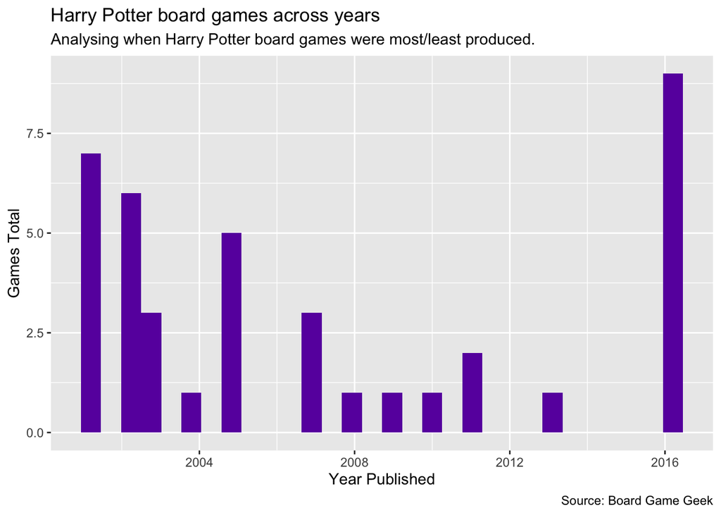

```r
board_game_data %>% ggplot() +
  geom_histogram(aes(x=year_published), fill = "#6a0dad") +
  labs(title = "Harry Potter board games across years",
       subtitle = "Analysing when Harry Potter board games were most/least produced.",
       caption = "Source: Board Game Geek",
       x = "Year Published",
       y = "Games Total")
```

```css
@import url('https://fonts.googleapis.com/css2?family=Palette+Mosaic&family=Red+Hat+Mono:wght@300&family=Roboto:wght@300&display=swap');

h2 {font-family: 'Red Hat Mono', monospace;}
body {
  font-family: 'Roboto', sans-serif;
}
```

I tried to visualise which years Harry Potter games were released the most and the least, and in doing that hoped to find out a correlation between Harry Potter movie release years and the board game years.

I believe I found such a correlation although my data doesn’t contain any information about the release dates of the movies. For example, when the first couple Harry Potter movies came out (early 2000s), we observe a high number of board games being released, while after the last movie (released in 2011) almost no board games were released. That is until 2016, when *Harry Potter and the Cursed Child* book were released.

## Learning reflection

I had never heard anything about JSON files until the Module 3 *Creating new variables and data tables*. I have learned that JSON files are a great and quite an intuitive way to store data. It was super easy to read and it was great to **learn to store multiple values in a column by nesting in JSON**. It is fairly different to work with them, though, so it was great to learn all about JSON files.

I am extremely excited about exploring further the nuts and bolts of *Grammar of Graphics* during the course of the rest of the semester. We have tried using *ggplots* to some extent but I know that *ggplot* is a limitless package and I am super excited to work with it again soon.